title: “Reproducible Research: Peer Assessment 1”

##1. Reading Dataset & processing data

```r
data <- read.csv("./activity.csv", header = TRUE)
datac <-data.frame(data)
datac[is.na(datac)]<-0

datasub <- tapply(data$steps, data$date, sum, na.rm = TRUE)
datasub <- data.frame(datasub)
colnames(datasub)[1] = "Steps"
```

##2. Histogram of the total number of steps taken each day

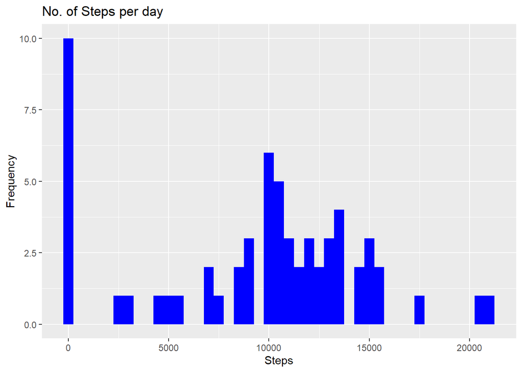

```r
library(ggplot2)
ggplot(datasub, aes(x = Steps)) + geom_histogram(fill = "blue", binwidth = 500) + labs(title = "No. of Steps per day", x = "Steps", y = "Frequency")
```

##3. Mean and median number of steps taken each day

```r
datamean <- mean(datasub$Steps)
datamedian <- median(datasub$Steps)
```

[output not shown]

##4. Times series plot of the average number of steps taken, per 5 min block (ref interval)

```r
data <- read.csv("./activity.csv", header = TRUE)
data[is.na(data)] <-0
Averagesteps <- as.numeric(tapply(data$steps, data$interval, mean, na.rm = TRUE))
Averagesteps
```

[output not shown]

[output cut: 43 more lines]

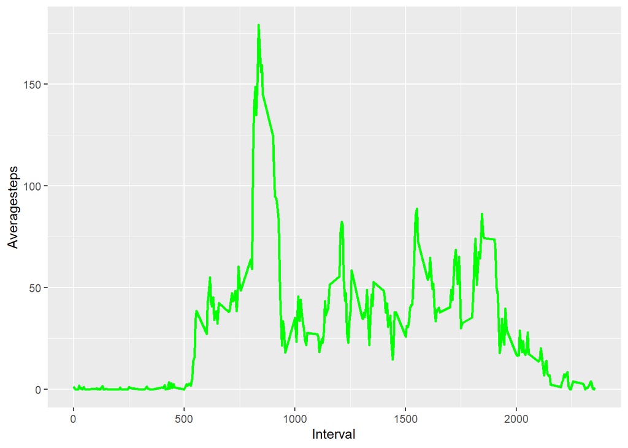

```r
Interval <- unique(data$interval, incomparables = FALSE)

Averagesteps <- data.frame(Interval, Averagesteps)

ggplot(data = Averagesteps, aes(x = Interval, y = Averagesteps)) + geom_line(color = "green", size = 1)
```

##5. The 5-minute interval that, on average, contains the maximum number of steps

```r
summary(Averagesteps)
```

```
##     Interval       Averagesteps
##  Min.   :   0.0   Min.   :  0.00
##  1st Qu.: 588.8   1st Qu.:  2.16
##  Median :1177.5   Median : 29.64
##  Mean   :1177.5   Mean   : 32.48
##  3rd Qu.:1766.2   3rd Qu.: 45.91
##  Max.   :2355.0   Max.   :179.13
```

```r
Averagesteps[which.max(Averagesteps[,2]), ]
```

```
##     Interval Averagesteps
## 104      835     179.1311
```

According to the information above, on average, the 5-min interval at 8:35am contains the maximum number of steps

##6. Code to describe and show a strategy for imputing missing data

```r
data <- read.csv("./activity.csv", header = TRUE)
##sum of missing values in data frame
sum(is.na(data$steps))
```

```
## [1] 2304
```

```r
summary(data)
```

```
##      steps            date              interval
##  Min.   :  0.00   Length:17568       Min.   :   0.0
##  1st Qu.:  0.00   Class :character   1st Qu.: 588.8
##  Median :  0.00   Mode  :character   Median :1177.5
##  Mean   : 37.38                      Mean   :1177.5
##  3rd Qu.: 12.00                      3rd Qu.:1766.2
##  Max.   :806.00                      Max.   :2355.0
##  NA's   :2304
```

```r
##As indicated in the summary below, we can find the mean value of the non missing data to be 37.38.

imputeddata <- data
imputeddata[is.na(imputeddata)] <- 37.38
```

##7. Histogram of the total number of steps taken each day after missing values are imputed

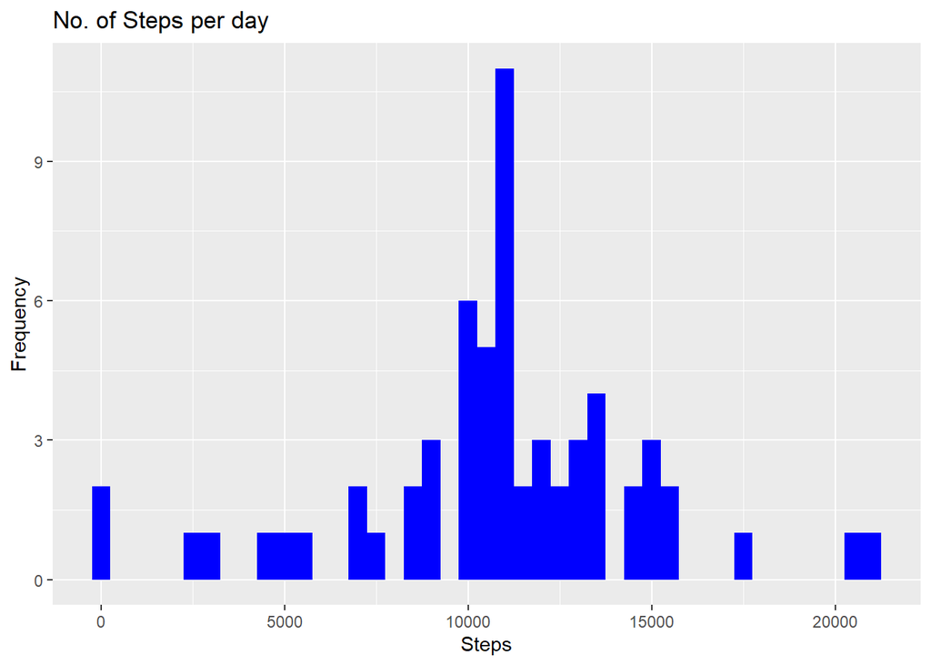

```r
imdatasub <- tapply(imputeddata$steps, imputeddata$date, sum, na.rm = TRUE)
imdatasub <- data.frame(imdatasub)
colnames(imdatasub)[1] = "Steps"

library(ggplot2)
ggplot(imdatasub, aes(x = Steps)) + geom_histogram(fill = "blue", binwidth = 500) + labs(title = "No. of Steps per day", x = "Steps", y = "Frequency")
```

##8.Panel plot comparing the average number of steps taken per 5-minute interval across weekdays and weekends

```r
data <- read.csv("./activity.csv", header = TRUE)
imputeddata <- data
imputeddata[is.na(imputeddata)] <- 37.38

wkd <- as.Date(imputeddata$date)
wkd1 <- weekdays(wkd, abbreviate=TRUE)

weekdayimdata <- data.frame(imputeddata, wkd1)

##Weekend dataset
weekenddata <- subset(weekdayimdata, grepl("^S", weekdayimdata$wkd1))
Averagestepswknd <- data.frame(tapply(weekenddata$steps, weekenddata$interval, mean, na.rm = TRUE))
weekenddatac <- data.frame(Averagestepswknd, weekenddata$interval, 1)
colnames(weekenddatac)[2] = "Interval"
colnames(weekenddatac)[3] = "X2"
colnames(weekenddatac)[1] = "AvgSteps"

##Weekday dataset
Mondata <- subset(weekdayimdata, grepl("Mon", weekdayimdata$wkd1))
Mondatac <- data.frame(Mondata, 2)
Tuedata <- subset(weekdayimdata, grepl("Tue", weekdayimdata$wkd1))
Tuedatac <- data.frame(Tuedata, 2)
Weddata <- subset(weekdayimdata, grepl("Wed", weekdayimdata$wkd1))
Weddatac <- data.frame(Weddata, 2)
Thudata <- subset(weekdayimdata, grepl("Thu", weekdayimdata$wkd1))
Thudatac <- data.frame(Thudata, 2)
Fridata <- subset(weekdayimdata, grepl("Fri", weekdayimdata$wkd1))
Fridatac <- data.frame(Fridata, 2)

##Final dataset, Weekend = 1 & Weekday = 2
WKDYfinalset <- rbind(Mondatac, Tuedatac, Weddatac, Thudatac, Fridatac)

Averagestepswkdyfinal <- data.frame(tapply(WKDYfinalset$steps, WKDYfinalset$interval, mean, na.rm = TRUE))
weekdayfinal <- data.frame(Averagestepswkdyfinal, WKDYfinalset$interval, 2)
```

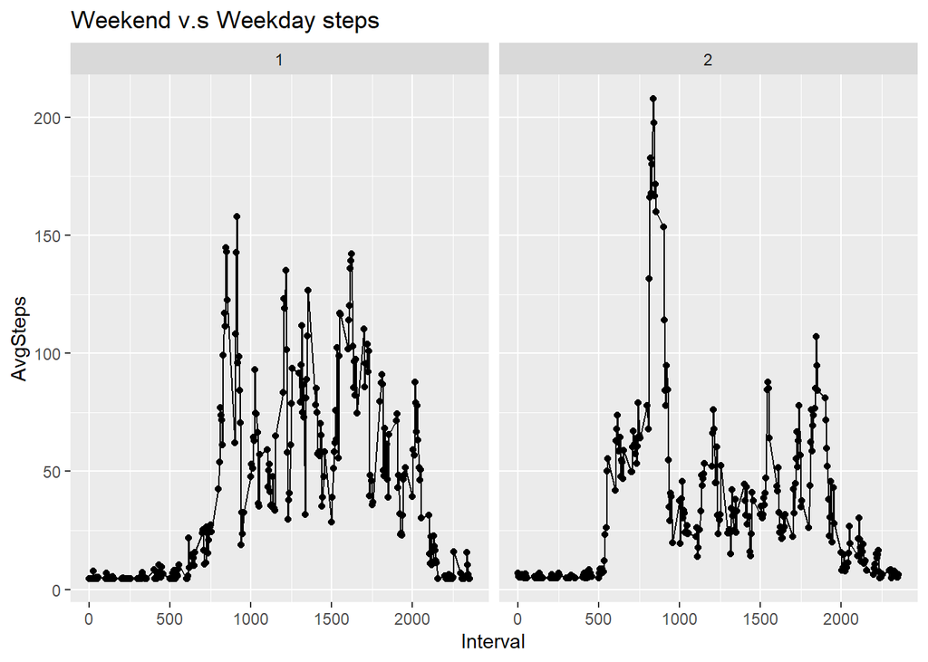

```r
colnames(weekdayfinal)[2] = "Interval"
colnames(weekdayfinal)[3] = "X2"
colnames(weekdayfinal)[1] = "AvgSteps"

finalplot <- rbind(weekenddatac, weekdayfinal)
AvgSteps <- finalplot$AvgSteps

library(ggplot2)
qplot(Interval, AvgSteps, data = finalplot, facets =  .~finalplot$X2, type = "l", main = "Weekend v.s Weekday steps") + geom_line(method = "lm", type = "l")
```